Review Article

Glucagon-like peptide-1 receptor

agonists as neuroprotective agents for

ischemic stroke: a systematic scoping

review

Mark P Maskery<sup>1,2</sup>

, Christian Holscher<sup>3</sup>

,

Stephanie P Jones<sup>4</sup>, Christopher I Price<sup>5</sup>, W David Strain<sup>6</sup>,

Caroline L Watkins<sup>4</sup>, David J Werring<sup>7</sup>and

Hedley CA Emsley<sup>1,2</sup>

Abstract

Stroke mortality and morbidity is expected to rise. Despite considerable recent advances within acute ischemic stroke

treatment, scope remains for development of widely applicable neuroprotective agents. Glucagon-like peptide-1 recep-

tor agonists (GLP-1RAs), originally licensed for the management of Type 2 Diabetes Mellitus, have demonstrated pre-

clinical neuroprotective efficacy in a range of neurodegenerative conditions. This systematic scoping review reports the

pre-clinical basis of GLP-1RAs as neuroprotective agents in acute ischemic stroke and their translation into clinical trials.

We included 35 pre-clinical studies, 11 retrospective database studies, 7 cardiovascular outcome trials and 4 prospective

clinical studies. Pre-clinical neuroprotection was demonstrated in normoglycemic models when administration was

delayed by up to 24 h following stroke induction. Outcomes included reduced infarct volume, apoptosis, oxidative

stress and inflammation alongside increased neurogenesis, angiogenesis and cerebral blood flow. Improved neurological

function and a trend towards increased survival were also reported. Cardiovascular outcomes trials reported a signif-

icant reduction in stroke incidence with semaglutide and dulaglutide. Retrospective database studies show a trend

towards neuroprotection. Prospective interventional clinical trials are on-going, but initial indicators of safety and

tolerability are favourable. Ultimately, we propose that repurposing GLP-1RAs is potentially advantageous but appro-

priately designed trials are needed to determine clinical efficacy and cost-effectiveness.

Keywords

Acute stroke, neuroprotection, reperfusion, clinical trials, animal models

Received 2 January 2020; Accepted 18 July 2020

Introduction

Stroke accounts for 6.5 million deaths per year globally

and by 2030 will result in an annual loss of over 200

million disability-adjusted life years.<sup>1,2</sup>With an increas-

ing number of strokes occurring in younger patients,

alongside an increased number of stroke survivors, the

cost of post-stroke care is rising. There is, therefore,

signiﬁcant scope to improve upon the current position.

Considerable advances have been made in acute

ischemic stroke (AIS) treatment, notably reperfusion

therapies, but these are limited to 10–20% of total

stroke patients following careful clinical and radiolog-

ical selection.<sup>3</sup>Even when intravenous thrombolysis

and/or endovascular thrombectomy are administered,

1Lancaster Medical School, Lancaster University, Lancaster, UK

2Department of Neurology, Royal Preston Hospital, Preston, UK

3Research and Experimental Center, Henan University of Chinese

Medicine, Zhengzhou, Henan Province, China

4Faculty of Health and Wellbeing, University of Central Lancashire,

Preston, UK

5Institute of Neuroscience, Stroke Research Group, Newcastle

University, Newcastle, UK

6NIHR Exeter Clinical Research Facility and Institute of Biomedical and

Clinical Science, University of Exeter Medical School, Royal Devon &

Exeter NHS Foundation Trust, Exeter, UK

7Stroke Research Centre, Department of Brain Repair and Rehabilitation,

UCL Institute of Neurology and The National Hospital for Neurology

and Neurosurgery, London, UK

Corresponding author:

Mark Maskery, Department of Neurology, Royal Preston Hospital,

Lancashire Teaching Hospitals NHS Foundation Trust, Sharoe Green

Lane, Preston PR2 9HT, UK.

Email: Mark.Maskery@doctors.org.uk

Journal of Cerebral Blood Flow &

Metabolism

2021, Vol. 41(1) 14–30

! The Author(s) 2020

Article reuse guidelines:

sagepub.com/journals-permissions

DOI: 10.1177/0271678X20952011

journals.sagepub.com/home/jcbfm

reduction in disability is highly time dependent.<sup>4,5</sup>

Scope remains for further improvement, especially for

patients who are unsuitable for reperfusion therapies or

those within remote environments.

Using simpler clinical selection processes, neuropro-

tective therapies could bring beneﬁts to a wider patient

group. Neuroprotectants could also enhance the bene-

ﬁts of reperfusion therapies by preservation of the

ischemic penumbra and reduction in ischemic reperfu-

sion injury. Despite many demonstrating pre-clinical

potential, a suitable agent has not yet been identiﬁed

by translational studies.<sup>6</sup>There remains a multitude of

factors affecting the translation from bench-to-bedside.

Namely, animal models are not perfect in their repre-

sentation of the heterogeneity of clinical stroke.<sup>7</sup>Stroke

in

humans

occurs

in

the

context

of

ageing,

co-morbidity (hypertension, diabetes mellitus, atrial

ﬁbrillation, pre-existing cerebrovascular disease) and

concomitant medication use.<sup>8</sup>Furthermore, factors

such as gender, cerebral blood ﬂow, body temperature

and glycemic status may inﬂuence stroke mechanism

and outcomes associated with therapy.<sup>6,9–11</sup>

Glucagon-Like Peptide-1 (GLP-1) receptor agonists

are gaining increasing momentum as possible neuro-

protective agents in AIS. GLP-1 is an incretin hor-

mone. Alongside its role in insulin secretion from the

pancreas and glucagon suppression, it also crosses the

blood-brain barrier (BBB) and promotes synaptic func-

tion, enhances neurogenesis, reduces apoptosis and

protects neurons from oxidative stress.<sup>12</sup>GLP-1 is pro-

duced in the brain and receptors are distributed

throughout

the

central

nervous

system.<sup>13</sup>

GLP-1

Receptor Agonists (GLP-1RAs), licensed for Type 2

Diabetes Mellitus (T2DM) have already demonstrated

pre-clinical neuroprotective efﬁcacy in Alzheimer’s

Disease and clinical trials in neurodegenerative condi-

tions are ongoing.<sup>12,14</sup>

The aim of this systematic scoping review is to

report the pre-clinical basis of GLP-1RAs as neuropro-

tective agents in AIS and their translation into clinical

trials. In addition to describing the characteristics and

quality of studies, the objectives are to speciﬁcally con-

sider timing of administration, association with glyce-

mic status, neuroprotective outcomes and application

to clinical care.

Materials and methods

Eligibility criteria

Pre-clinical: We included pre-clinical in vivo studies

which administered naturally occurring GLP-1, a

mimetic or analogue, before, during or after stroke

induction. Normoglycemic, hyperglycemic and induced

T2DM models were included.

Studies were excluded if their only focus was hem-

orrhagic stroke as this does not reﬂect the proposed

mechanism for how GLP-1 is involved in ischemic

tissue injury. Those studies which reported incidence

of hemorrhagic transformation as a complication of

AIS

were

included

as

these

reﬂect

post-stroke

complications.

Clinical: We included all prospective clinical trials

which administered GLP-1RAs before, during or

after stroke onset with outcome measures deﬁned to

identify neuroprotective efﬁcacy by way of stroke

volume reduction or improvement in post-stroke func-

tion or mortality. We also included any potential fea-

sibility or safety-based studies in this area.

Our scoping searches identiﬁed that very few pro-

spective clinical trials measuring stroke outcomes were

available. Pragmatically, we therefore also included all

retrospective database analyses of stroke incidence or

composite cardiovascular outcomes in patients treated

with GLP-1RAs. Furthermore, we included cardiovas-

cular outcome trials (CVOTs) of GLP-1RAs to evalu-

ate the incidence of stroke in this relatively higher risk

cohort.

Studies were excluded if their full-text was not avail-

able or not published in English. Efforts were made to

contact authors directly to obtain any missing articles

or data.

Database search strategy

After several initial scoping searches,<sup>15</sup>we accessed

Web

of

Science

on

19

March

2020

to

search

MEDLINE, Web of Science core collection, BIOSIS

and SciELO from 1 January 2000. Keywords were

EITHER ‘GLP(-)1, glucagon like peptide(-)1, exena-

tide, liraglutide, lixisenatide, albiglutide, dulaglutide,

semaglutide’ AND EITHER ‘stroke, CVA, cerebrovas-

cular, h(a)emorrhage, small vessel disease’. Articles

were cross-referenced and references were searched to

identify further studies of interest.

All articles/studies were screened independently in

an unblinded, standardised manner by MM and HE

by way of title and abstract to identify those suitable

for full-text review. Queries and disagreements were

resolved by discussion. Preferred Reporting Items for

Systematic Reviews and Meta-Analyses (PRISMA)

guidelines

were

applied.

Pre-clinical

studies

were

appraised according to Animal Research: Reporting

of In Vivo Experiments (ARRIVE) guidelines,<sup>16</sup>and

the

updated

Stroke

Therapy

Academic

Industry

Roundtable Preclinical Recommendations (STAIR)

guidelines.<sup>7</sup>Data supporting the ﬁndings of this

review are available from the corresponding author

upon reasonable request.

Maskery et al.

15

Results

Study selection

The literature search identiﬁed 797 results (see Figure 1)

alongside 10 from other sources. After removal of dupli-

cates, this left 794 for screening. We excluded 593

articles based upon title and review of abstract leaving

201 full text articles to review. In total, 35 preclinical

studies, 11 retrospective database studies, 7 cardiovascu-

lar outcome trials and 4 prospective clinical studies met

the inclusion criteria.

Pre-clinical studies

Characteristics of included studies. As shown in

Table 1, 35 pre-clinical studies were included within

this review. Studies were completed between 2009 and

2020. Studies were predominantly based upon mouse

and rat models of stroke; however, one study utilised a

gerbil model.<sup>17</sup>Stroke induction was either via tran-

(CCAO)

or

middle

cerebral

artery

occlusion

(MCAO). Most studies induced unilateral occlusion

in keeping with spontaneously occurring stroke onset

in humans, but six studies utilised a bilateral occlusion

model. Cerebral ischemia was induced by either liga-

tion, ﬁlament occlusion or ablation of the relevant

artery.

Twelve studies administered exendin-4,<sup>17–28</sup>nine

one study each reported the utility of semaglutide,<sup>43</sup>

PEx-4

(exendin-4

loaded

poly-microspheres),<sup>44</sup>

proGLP-1 (long acting GLP-1RA),<sup>45</sup>DMB (GLP-1R

agonist/modulator),<sup>46</sup>dual GLP-1/Glucose-dependent

Insulinotropic

Peptide

(GIP)

agonist

(GLP-1/GIP

DA),<sup>47</sup>oxyntomodulin (co-activates GLP-1R and glu-

cagon receptor),<sup>48</sup>P7C3 (aminopropyl carbazole com-

pound)<sup>49</sup>and one study directly compared exendin-4

with liraglutide.<sup>50</sup>In eight studies, GLP-1R antago-

nists, such as Ex-9-39, were administered to study the

role

of

the

GLP-1R

in

neuroprotective

mecha-

nisms.<sup>19,21–23,41,45,46,49</sup>

Two studies investigated multiple doses of GLP-

1RAs to compare neuroprotective efﬁcacy and con-

cluded that neuroprotection was dose-dependent.<sup>20,51</sup>

Most studies administered GLP-1RAs via intraper-

itoneal, subcutaneous or transvenous routes. However,

Zhang et al. reported neuroprotection with both oral

DMB<sup>46</sup>and intranasal exendin-4.<sup>22</sup>

Some 14 studies administered GLP-1RAs chroni-

cally prior to the onset of stroke. Clinically, this

would represent those patients who receive GLP-

1RAs

as

part

of

routine

T2DM

management

and then go on to experience AIS.<sup>18,19,22,23,29,31,38,</sup>

39,42,44–46,48,51

Chronic

pre-treatment

occurred

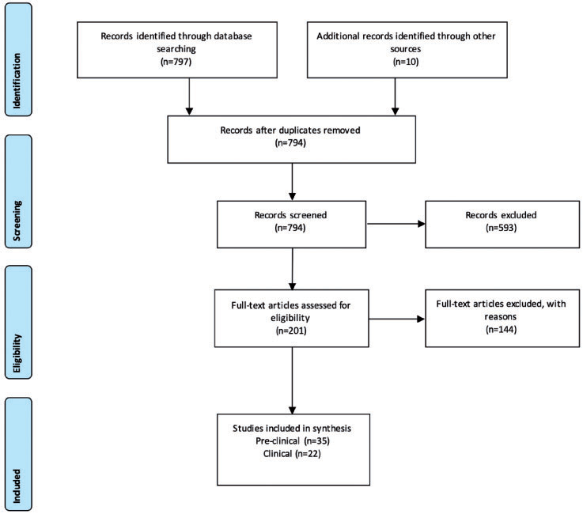

Figure 1. PRISMA flow chart demonstrating the selection of studies.

16

Journal of Cerebral Blood Flow & Metabolism 41(1)

Table 1. Overview of the pre-clinical studies.

Author

Year

Animal

model

Co-morb.

Drug

Admin

route

Sub-studies

Stroke

induction

(time/min)

Administration time (min)

Pre-

ischemia

Post-

ischemia

Main outcomes (NP – Neuroprotective)

GLP-1RA administered prior to stroke onset (including chronic pre-treatment)

Li et al.18

2009 Rat

Ex-4

i.c.v.

u.l tMCAO (60)

15

NP – # infarct volume and improves functional

outcome

Briyal et al.19

2012 Rat

Ex-4

i.p.

BQ123

u.l. pMCAO

BD – 7 days

NP – # infarct volume, # motor deficit, # oxidative

stress parameters (# MDA, " GSH, " SOD) NP

via # oxidative stress and independent of

endothelin receptor.

Briyal et al.29

2014 Rat

DM

Liraglutide

s.c.

Non-diabetic, insulin

u.l. pMCAO

OD – 14 days

NP – # infarct volume, # motor deficit, # oxidative

stress parameters (# MDA, " GSH, " SOD),

# apoptosis (" Bcl-2, # Bax). NP in both non-

diabetic & DM models with similar infarct

volume reduction, insulin treatment did not

reduce infarct volume.

Chien et al.44

2015 Rat

DM

PEx-4

s.c.

Non-diabetic, Ex-4

b.l tCCAO (10)

& hypotension

OD – 14 days

NP – # brain oedema, # cognitive deficit,

# oxidative stress, " cerebral blood flow. PEx-4

more NP than Ex-4 in DM.

Zhang et al.45

2015 Mouse

Pro-GLP-1

i.p.

shRNA

u.l. tMCAO (90)

OD – 7 days

NP – #infarct volume, # neurological deficit,

# apoptosis (" Bcl-2, # Bax). NP not glucose

dependent. NP blocked by shRNA (suggesting

GLP-1R mediated NP)

Jiang et al.38

2016 Rat

DM

rhGLP-1

i.p.

nimodipine, insulin

u.l. tMCAO (90)

TDS – 14 days

NP in DM– # infarct volume (more than insulin

group), # neurological deficit, # brain injury

markers (# S100B, # NSE, # MBP)

Zhang et al.46

2016 Mouse

DMB

p.o.

Ex-4, Ex-9-39, shRNA

u.l. tMCAO (60)

30

NP given orally– # infarct volume, # neurological

deficit, # apoptosis (" Bcl-2, # Bax). No impact

on plasma insulin and glucose levels in non-

diabetic mice. DMB activation of GLP-1R dif-

ferent to Ex-4. NP blocked by shRNA but not

by Ex-9-39.

Zhang et al.22

2016 Mouse

Ex-4

i.n.

Intraperitoneal Ex-4, shRNA

u.l. tMCAO (90)

OD – 7 days

NP given intranasally – # infarct volume,

# neurological deficit, # apoptosis (# caspase-3)

Intranasal route produced " CNS concentra-

tion than intraperitoneal No impact on plasma

insulin and glucose levels and NP was blocked

by shRNA suggesting NP is GLP-1R mediated.

Kim et al.23

2017 Rat

Ex-4

i.c.v

Ex-9-39

u.l. MCAO (60)

30

NP – # infarct volume (by up to 75%),

# neurological deficit, # oxidative damage/

inflammation (# COX-2, # PE2)

Li et al.48

2017 Rat

OXM

i.c.v.

u.l. tMCAO (60)

15

NP – # infarct volume, " locomotive activity

Abdel-latif et al.42 2018 Rat

DM

Lixisenatide

i.p.

glimepiride

b.l. tCCAO (30)

OD – 14 days

NP – # infarct volume, # neurological deficit,

# oxidative stress (# MDA, " GSH, " catalase),

# inflammation/apoptosis (# caspase-3, # TNF-

a). Lixisenatide more NP than glimepiride.

Fang et al.39

2018 Rat

DM

rhGLP-1

i.p.

nimodipine

u.l. tMCAO (90)

TDS – 14 days

NP – # infarct volume, # neurological deficit,

# oxidative stress parameters (# MDA," GSH,

" SOD), # apoptosis (" Bcl-2, # Bax, # caspase-

3), "EAAT2,

(continued)

Maskery et al.

17

Table 1. Continued.

Author

Year

Animal

model

Co-morb.

Drug

Admin

route

Sub-studies

Stroke

induction

(time/min)

Administration time (min)

Pre-

ischemia

Post-

ischemia

Main outcomes (NP – Neuroprotective)

Filchenko et al.31

2018 Rat

DM

Liraglutide

s.c.

Non-diabetic, metformin

u.l. tMCAO (30)

OD – 7 days

NP – # infarct volume, # neurological deficit only in

non-DM model, NP not associated with gly-

cemic control amelioration (Metformin not NP)

Gad et al.51

2020 Rat

Lixisenatide

i.p.

0.7 and 7 nmol/kg lixisenatide

b.l. tCCAO (60)

OD – 14 days

NP – # oxidative stress parameters (# MDA,

" GSH, " SOD), # apoptosis (" Bcl-2, # Bax,

# caspase-3), # inflammatory markers (# MPO,

# IL-1b, # TNF-a), " viable hippocampal neu-

rons on histological staining.

Higher dose

Lixisenatide " NP

GLP-1RA administered prior to and following stroke onset

Hyun Lee et al.17

2011 Gerbil

Ex-4

i.p.

b.l. tCCAO (5)

120

60

NP – # neurological deficit, " GLP-1R immunore-

activity, # microglial activation

Darsalia et al.20

2012 Rat

DM

Ex-4

i.p.

0.1, 2 or 5mg/kg of Ex-4

u.l. tMCAO (90)

BD – 4 weeks

BD –2–4 weeks

NP – # infarct volume (no difference between 2 &

4 weeks post MCAO), # microglial infiltration

but marginal effect on activation, " stem cell

proliferation & neuroblast formation.

NP is

dose dependent.

Jia et al.21

2015 Rat

Ex-4/Catapol

i.c.v.

Ex-9-39

u.l. tMCAO (60)

15

0

NP – # infarct volume, # neurological deficit,

" hippocampal b-endorphin expression, NP

blocked by Ex-9-39, b-endorphin anti-serum

and naloxone

Deng et al.30

2018 Rat

DM

Liraglutide

i.p.

Non-DM

u.l. pMCAO

BD – 7 days

BD – 7 days

NP- # infarct volume, # neurological deficit,

# oxidative stress (" SOD), # inflammation

(# MPO), " Nrf2, " HO-1 (antioxidative stress

signalling pathway) No significant difference in

NP between DM & non-DM

GLP-1RA administered following stroke onset (including delayed administration)

Teramoto et al.24

2011 Mouse

Ex-4

t.v.

u.l tMCAO (60)

0,60,180

NP – # infarct volume, # neurological deficit,

# oxidative stress, # inflammation (# microglial

activation), " intracellular cAMP levels (due to

GLP-1R activation). NP probably mediated via

raised intracellular cAMP levels

Sato et al.32

2013 Rat

Liraglutide

i.p.

u.l. tMCAO (90)

60

NP – # infarct volume, # neurological deficit,

# oxidative stress, " VEGF in cortex but not in

the striatum.

Darsalia et al.25

2014 Mouse

DM

Ex-4

i.p.

2 month old &

14 month obese/DM mice

u.l. tMCAO (30)

90, 180 or 270

then OD 1 week

NP – " neuronal survival, " M2 microglial markers

Non statistically significant reduction in pro-

inflammatory markers. NP in non-DM/DM at

50mg/kg at 90/180 min and at 90 min for 5mg/

kg. Stroke volume not affected by Ex-4

administration. Not NP when Ex-4 adminis-

tered 4.5hrs after stroke onset. NP in both

young and old animal models

Zhao et al.40

2015 Rat

DM

rhGLP-1

i.p.

nimodipine

u.l. tMCAO (120)

0

(continued)

18

Journal of Cerebral Blood Flow & Metabolism 41(1)

Table 1. Continued.

Author

Year

Animal

model

Co-morb.

Drug

Admin

route

Sub-studies

Stroke

induction

(time/min)

Administration time (min)

Pre-

ischemia

Post-

ischemia

Main outcomes (NP – Neuroprotective)

NP – # infarct volume, " neuronal survival,

# oxidative stress (# MDA, " GSH, " SOD),

# nitric oxide damage (iNOS, eNOS)

Statistically significant reduction in blood glu-

cose in high dose group (no hypoglycemia)

Han et al.47

2016 Rat

GLP-1/GIP (DA)

i.p.

GLP-1RA (SA)

u.l. tMCAO (60)

60

NP – # infarct volume, # neurological deficit,

# apoptosis (" Bcl-2, # Bax), # nitric oxide

damage (iNOS). DA more NP than SA.

Chen et al.26

2016 Mouse

Warfarin & Ex-4

t.v.

P13K inhibitor

u.l. tMCAO (45)

0

NP – # infarct volume, # neurological deficit, " BBB

integrity, # oxidative stress (# 8-OHdG, #

HHE), # inflammation, NP blocked by P13K

inhibitor. Ameliorated warfarin associated

hemorrhagic transformation.

Kuroki et al.27

2016 Mouse

DM

Ex-4

i.p.

insulin

u.l. tMCAO (60)

60

Hyperglycemia associated with " infarct volume,

" cerebral oedema, " hemorrhagic transforma-

tion. Ex-4 NP – # infarct volume, # cerebral

oedema, # oxidative stress, # inflammation

(# TNF-a), # MMP-9 activation, # Iba-1 positive

microglia, NP in hyperglycemic model. Insulin

not NP.

Li et al.50

2016 Mouse

DM

Ex-4 or liraglutide i.p.

u.l. tMCAO (60)

0, 3, 6 or 12hrs

NP – # neurological deficit including # bladder

dysfunction, " cerebral microcirculation.

# cerebral oedema, # oxidative stress (# DHE,

# ROS, " SOD), # apoptosis (# caspase-3,

# TUNEL, # Bax, # PARP, " Bcl-2),

# inflammation (# ICAM-1, NF-2jB, p50, p65).

Yang et al.28

2016 Rat

Ex-4

t.v.

u.l. tMCAO &

b.l. tCCAO (60)

0 & 24hrs

NP – # DNA damage (" APE1, # TUNEL)

Zhu et al.33

2016 Rat

Liraglutide

s.c.

u.l pMCAO

1hr, then OD for

1, 3 and 7 days

NP – # infarct volume, # neurological deficit,

# apoptosis (# ROS, # caspase-3, -8, -9, # PARP,

" Bcl-2, # Bax), # DNA damage (# TUNEL),

# stress related hyperglycemia without causing

hypoglycemia.

Dong et al.34

2017 Rat

Liraglutide

s.c.

u.l. MCAO (90)

24hrs, then OD

for 4 weeks

NP – # neurological deficit, " GLP-1R expression,

" glucose metabolism in ischemic penumbra

(18-FDG-PET)

" neurovascular remodelling

(" NeuN, " GFAP, " vWF). NP when first dose

delayed by 1 day

Abdel-latif et al.41 2018 Rat

Lixisenatide

i.p.

Ex-9-39, pentoxyphylline

b.l. tCCAO (30)

1 & 24hrs

NP – # infarct volume, # neurological deficit,

# apoptosis (caspase-3), # oxidative stress

(# GSH, # MDA, # catalase, # NO),

# inflammation (TNF-a) – these effects not

inhibited by GLP-1R antagonist Ex-39 suggest-

ing GLP-1R independent pathway.

(continued)

Maskery et al.

19

Table 1. Continued.

Author

Year

Animal

model

Co-morb.

Drug

Admin

route

Sub-studies

Stroke

induction

(time/min)

Administration time (min)

Pre-

ischemia

Post-

ischemia

Main outcomes (NP – Neuroprotective)

Chen et al.35

2018 Mouse

Liraglutide

i.p.

u.l. pMCAO

24hrs, then OD for 14 days NP – # infarct volume, # neurological deficit,

" angiogenesis ("VEGF)

No significant differ-

ence in blood glucose levels between liraglutide

and controls (as expected, stimulated insulin

release is in a blood-glucose dependent

manner). NP when first dose delayed by 1 day

Wang et al.49

2018 Mouse

P7C3

t.v.

Ex-9-39

u.l. tMCAO (40)

120

NP – # neurological deficit, " neurogenesis

(" doublecortin, " b-tub3, " adam11,

" adamts20, # GSK-3)

NP is GLP-1R

dependent.

Yang et al.43

2019 Rat

Semaglutide

i.p.

Blood glucose monitoring

u.l. pMCAO

2hrs, then alternate

days 1,7,14 or 21 days

NP – # infarct volume, # neurological deficit,

# neuronal loss, # apoptosis (" Bcl-2, # Bax,

# caspase-3), " neurogenesis, improved growth

factor signalling (" ERK1, " ERS-1), No hypo-

glycemia in normoglycemic model.

He et al.36

2019 Mice

Liraglutide

i.p.

u.l. pCCAO

OD for 7 days

NP – # neurological deficit, # oxidative stress

Zeng et al.37

2020 Rat

Liraglutide

i.p.

P13k inhibitor

u.l pMCAO

0 then OD

NP – # infarct volume, # cerebral oedema,

# apoptosis ( " Bcl-2, # caspase-3, # TUNEL),

# inflammation (# TNF-a, IL-18, IL-1b, IL-6,

COX-2) P13k inhibitor partially reversed NP

effects.

SA: single agonist; DA: dual agonist; Ex-4- exendin-4; PEx-4: Exendin-4 loaded poly-microspheres; Ex-9-39: GLP-1R antagonist; pro-GLP-1: long acting GLP-1RA; rhGLP-1: recombinant human GLP-1; DMB:

6,7-dichloro-2-methyl-sulfonyl-3-N-tert-butylaminoquinoxaline; OXM: oxyntomodulin; shRNA: small hairpin RNA (targets GLP-1R); BQ123- endothelin receptor antagonist; P7C3- aminopropyl carbazole

compound; i.p.: intraperitoneal; s.c.: subcutaneous; p.o.: oral; i.n.: intranasal; t.v.: transvenous; i.c.v.: intracerebroventricular; OD/BD/TDS: once/twice/three times daily; DM: diabetes mellitus; Non-DM: non

diabetes mellitus (healthy); u.l.: unilateral; b.l.: bilateral; MCAO: middle cerebral artery occlusion; CCAO: common carotid artery occlusion; (t/p)MCAO: transient/permanent; SOD: superoxide dismutase;

MDA: malondialdehyde; GSH: glutathione; 8-OHdG: 8-hydroxy-2-deoxyguanosine; HHE: 4-hydroxyhexenal; DHE: dihydroethidium; ROS: reactive oxygen species; Bcl-2: B cell lymphoma 2; Bax: Bcl-2-like

protein 4; Caspase-3; PARP: poly-ADP ribose polymerase; TUNEL: terminal deoxynucleotidyl transferase dUTP nick end labeling; S100b: s100- calcium binding protein B; NSE: neuron specific enolase; MBP:

myelin basic protein; COX-2: cyclo-oxygenase-2; PE2: Prostaglandin E2; EAAT2: Excitatory amino acid transporter-2; MPO: myeloperoxidase; HO-1: heme oxygenase-1; Nrf2: nuclear factor erythroid-2;

NOS: nitric oxide synthase; BBB: blood brain barrier; MMP-9: matrix metalloproteinase-9; ICAM-1: intracellular adhesion molecule-1; NeuN: neuronal nuclear protein (neuronal marker); GFAP: Glial

fibrillary acidic protein (glial marker); vWF: von Willebrand factor (endothelial marker); b-tub3: beta tubulin III; GSK-3: glycogen synthase kinase 3; IL: interleukin.

20

Journal of Cerebral Blood Flow & Metabolism 41(1)

between 14 days prior and 15 minutes prior to stroke

onset, for one to three times daily.

A further four studies administered GLP-1RAs

prior to and following stroke onset for between 0 and

four weeks – with dosing schedules of up to twice

daily.<sup>17,20,21,30</sup>

Most closely aligned with the proposed clinical

application of administering treatment to GLP-1RA

naı¨ve patients in the hyper-acute AIS setting, 17 studies

only administered the medication following stroke

onset.<sup>24–28,32–37,40,41,43,47,49,50</sup>First dose was delayed

between 0 min and 24 h post-onset and continued for

up to four weeks.

Alterations in physiological parameters such as

body temperature have the potential to impact the out-

come of stroke. Li et al. reported no signiﬁcant change

in body temperature when measured before and after

treatment with exendin-4.<sup>18</sup>We did not identify any

GLP-1RA study of AIS which varied temperature

between groups. Most studies regulated body temper-

ature within normal physiological parameters during

MCAO surgery and animals were housed within a

temperature-controlled environment.

Quality of included studies. Pre-clinical study meth-

odology was appraised according to the STAIR 2009

criteria, with a maximum available score of 7. Median

score was 3 (range 2–7). Inclusion/exclusion criteria

and reporting of potential conﬂicts of interest/funding

were consistently reported in 100% and 94% of studies,

respectively. Fewer studies commented on randomisa-

tion (54%), allocation concealment (17%) and blinded

assessment of outcome (43%). Only four studies (11%)

reported performing a sample size calculation.

Reporting of pre-clinical studies was also assessed

using the ARRIVE guidelines, with a maximum score

of 36. Median score was 22 (range 14–29). Methods,

statistical analysis, outcomes and conﬁdence intervals

were well reported, as were ethical and funding state-

ments, but the justiﬁcation for animal models, transla-

tion to human biology, limitations and adverse events

were frequently not reported.

Impact of hyperglycemia in stroke models. Twelve

studies were based on hyperglycemic rodents, with or

without a normoglycemic control group.

Kuroki et al. demonstrated that hyperglycemia was

associated with an increase in infarct volume, cerebral

edema and hemorrhagic transformation in a mouse

model that underwent transient, unilateral occlusion

of the MCAO for 60 min.<sup>27</sup>They reported that intra-

peritoneal administration of exendin-4 60 min after

stroke onset was associated with a reduction in these

parameters

which

was

not

replicated

by

insulin

monotherapy.

Briyal et al. reported that liraglutide reduced infarct

volume by a similar amount in both diabetic and nor-

moglyemic models, but this neuroprotection was again

not reproduced in the insulin treatment arm despite

resolution of hyperglycemia.<sup>29</sup>Deng et al. further con-

ﬁrmed neuroprotection was independent of glycemic

status prior to stroke onset.<sup>30</sup>Jiang et al. reported

that stroke infarct volume in the rhGLP-1 group was

signiﬁcantly reduced when compared to insulin treat-

ment.<sup>38</sup>Metformin was also shown to ameliorate

hyperglycemia but did not confer the additional neuro-

protective outcomes associated with liraglutide.<sup>31</sup>

One study demonstrated similar neuroprotective

outcomes between 2-month-old healthy mice and 14-

month-old overweight, diabetic mice treated with exen-

din-4.<sup>25</sup>

Whilst GLP-1RAs were associated with a reduction

in blood glucose in hyperglycemic models,<sup>40</sup>no study

reported hypoglycemia when GLP-1RAs were admin-

istered to normoglycemic models. This is to be expected

as GLP-1RA-associated insulin secretion from the pan-

creas is glucose dependent.<sup>35</sup>Indeed, Zhang et al. con-

cluded

that

neuroprotection

was

not

glucose

dependent.<sup>45</sup>

Yang et al. monitored blood glucose in rats which

underwent intraperitoneal administration of semaglu-

tide starting 2 h following unilateral permanent MCAO

occlusion, further demonstrating neuroprotection in

the absence of hypoglycemic episodes.<sup>43</sup>

Infarct volume and neuronal survival. Administration

of GLP-1RAs prior to, at the point of, or delayed fol-

lowing stroke onset were associated with reduction in

infarct volume. In total, nine studies demonstrated a

reduction in infarct volume with exendin-4,<sup>18–24,26,27</sup>

eight with liraglutide,<sup>29–33,35–37</sup>three with rhGLP-1,

three with lixisenatide and one with each of PEx-4,

proGLP-1, DMB, OXM, GLP-1/GIP DA and sema-

glutide. Liraglutide was associated with a reduction in

infarct volume when the ﬁrst dose was delayed by up to

1 day.<sup>35</sup>Kim et al. reported a reduction in infarct

volume by up to 75% in a rat model of transient

MCAO. Darsalia et al. reported that exendin-4 admin-

istration was associated with a reduction in stroke

volume when administered for four weeks prior to,

and

two

to

four weeks

following

stroke

onset.<sup>20</sup>

However, in a later study, whereby they only adminis-

tered exendin-4 following stroke onset, it did not sig-

niﬁcantly reduce infarct volume but did reduce overall

neuronal loss.<sup>25</sup>Reduction in neuronal loss was also

reported

with

semaglutide,<sup>43</sup>

rhGLP-1<sup>40</sup>

and

lixisenatide.<sup>51</sup>

Cellular function. Apoptosis represents a chain of

enzymatic

events

resulting

in

programmed

cell

Maskery et al.

21

death.<sup>52</sup>Whilst controlled apoptosis is essential for the

maintenance of homeostasis, dysregulated apoptosis,

for example in within the ischemic penumbra, can

result in increased cell death.<sup>53</sup>Bcl-2 is an anti-

apoptotic protein which functions at least in part by

reducing cytochrome C release from the mitochondria.

Conversely,

Bax

is

a

pro-apoptotic

protein

and

increases cytochrome C levels.<sup>52</sup>Increased Bcl-2 and

reduced Bax levels, contributing to an increased

Bcl-2:Bax ratio and representing reduced levels of apo-

ptosis, have been reported in three studies of liraglu-

tide<sup>29,33,37</sup>

and

one

study

for

each

pro-GLP-1,<sup>45</sup>

1/GIP DA<sup>47</sup>and semaglutide.<sup>43</sup>Critically, this reduc-

tion of apoptosis was reproduced in normoglycemic

models when administered after stroke onset.<sup>33,37,43,47</sup>

Caspase

proteins

are

also

pro-apoptotic

and

increased levels are associated with higher rates of

cell

death.<sup>54</sup>

Liraglutide,

exendin-4,

lixisenatide,

rhGLP-1 and semaglutide have been shown to reduce

levels

of

caspase-3

in

pre-clinical

models

of

stroke.<sup>33,37,39,41–43,46,50,51</sup>Zhu et al. have also demon-

strated reduced levels of caspase 8 and 9 in models

administered liraglutide.<sup>33</sup>

Cleavage of PARP by caspases is a signal of apo-

ptosis and has been implicated in cerebral ischemia.<sup>53</sup>

Reduction in PARP has been demonstrated with both

liraglutide and exendin-4 treatment.<sup>33,50</sup>

TUNEL assays detect DNA degradation during the

later stages of apoptosis and have demonstrated

reduced apoptotic activity with liraglutide and exen-

din-4.<sup>37,50,55</sup>

GLP-1RA administration following stroke induc-

tion has been associated with an anti-inﬂammatory

effect.<sup>26</sup>Tumor necrosis factor alpha (TNF-a) is a cyto-

kine synthesised by many cell lines, but particularly by

macrophages and microglia.<sup>56</sup>TNF-a is involved with

the inﬂammatory response following stroke onset.<sup>56</sup>

Five studies reported a reduction in TNF-a when com-

pared to controls, three with lixisenatide<sup>41,42,51</sup>and one

with each of liraglutide<sup>37</sup>and exendin-4.<sup>27</sup>Indeed, two

studies

reported

reduced

microglial

activation<sup>17,24</sup>

whilst a further study by Darsalia et al. reported

reduced microglial inﬁltration, but a marginal effect

on activation.<sup>20</sup>Reduced levels of other markers of

inﬂammation, such as myeloperoxidase and interleu-

kin, have also been reported.<sup>30,37,51</sup>

One study reported a non-statistically signiﬁcant

reduction in pro-inﬂammatory markers.<sup>25</sup>

There is also deterioration in markers of oxidative

stress following AIS. Twelve studies reported an

improvement in oxidative stress parameters following

GLP-1RA administration in AIS – ﬁve studies of exen-

din-4,<sup>19,24,26,27,50</sup>four studies of liraglutide,<sup>29,30,32,36</sup>

two

of

lixisenatide<sup>41,42</sup>

and

one

of

rhGLP.<sup>40</sup>

Predominantly, studies reported reduced levels of

malondialdehyde and increased concentrations of glu-

tathione and superoxide dismutase.

Dong et al. performed 18-FDG PET imaging in a

rat model of unilateral transient MCAO. In the ani-

mals treated with subcutaneous liraglutide, there was

radiological evidence of increased glucose metabolism

within the ischemic penumbra.<sup>34</sup>

Neurovascular

function. The

neurovascular

unit

incorporates both cellular and extracellular compo-

nents involved in the regulation of cerebral blood

ﬂow and blood-brain barrier function – it is involved

with the maintenance of cerebral homeostasis and con-

trol of cerebral blood ﬂow.<sup>57</sup>

GLP-1RAs have been shown to increase cerebral

blood ﬂow following AIS when compared with con-

trols.<sup>44</sup>Li et al. reported that cerebral microcirculation

is reduced following AIS, but improved to a similar

degree within 4–12 h after MCAO in diabetic mice

treated with either liraglutide or exendin-4 after stroke

induction.<sup>50</sup>Blood–brain barrier integrity has also been

shown to improve with GLP-1RA treatment.<sup>26</sup>

Vascular

endothelial

growth

factor

(VEGF)

known to promote angiogenesis and protect ischemic<sup>is</sup>

neurons from injury, demonstrating a crucial role in the

neurovascular remodelling post-AIS.<sup>58</sup>Chen et al.

demonstrated that intraperitoneal liraglutide therapy,

administered 24 h following stroke induction and

once daily for 14 days, was associated with increased

VEGF expression when compared with normal saline

treatment at days 7 and 14 post-AIS in a normoglyce-

mic model.<sup>35</sup>Similarly, Sato et al. demonstrated

upregulation of VEGF in the cerebral cortex of

liraglutide-treated, normoglycemic rats; however, this

was not seen within the striatum.<sup>32</sup>

Markers of neuronal, glial and endothelial function

(NeuN, GFAP and vWF respectively) were used by

Dong et al. to investigate for evidence of neurovascular

remodelling following AIS. They reported that liraglu-

cating increased remodelling associated with GLP-

1RAs following AIS.<sup>34</sup>

Jiang et al. reported that levels of brain injury

markers (S100B, NSE and MBP) were reduced with

both rhGLP-1 and nimodipine treatments.<sup>38</sup>

Wang et al. investigated for evidence of increased

neurogenesis

associated

with

GLP-1R

activation.

They reported that doublecortin (marker of newborn

neuroblasts) and b-tubulin III (marker of neurogenesis

and neural progenitor activity) levels were signiﬁcantly

upregulated with P7C3 treatment when compared to

controls. They also reported increased levels of cell

22

Journal of Cerebral Blood Flow & Metabolism 41(1)

proliferation markers (ki67, BrdU) and neurodevelop-

mental markers (adam11, adamts20) alongside markers

of increased neurogenesis (GSK-3 inhibition).<sup>49</sup>

Darsalia et al. also counted ki67 expressing cells to

evaluate stem cell proliferation and reported a two-fold

greater number of proliferating cells in the exendin-4

treatment group compared with controls at two weeks

following stroke induction; however, there was no

detectable

difference

at

four weeks.

Doublecortin

levels

were

also

increased

at

two weeks

in

the

exendin-4 treatment group, with no difference from

controls at four weeks. When using Neun and BrdU

expressing neurons to identify new, mature neurons

generated after stroke onset, there was no difference

between the treatment and control groups.

Doublecortin levels were also shown to be increased

with semaglutide treatment.<sup>43</sup>

Neurological outcomes. Assessment of neurological

outcomes was heterogeneous amongst studies, with

many utilising a range of different techniques or mod-

iﬁed adaptions. Overall, selected neurological assess-

ments

examined

both

cognitive

and

locomotive

neurological function.

Eight

studies

reported

a

reduction

in

post-

stroke neurological deﬁcit when treated with liraglu-

tide,<sup>29,31–36,50</sup>six with exendin-4,<sup>17–19,22,23,26</sup>two with

rhGLP-1,<sup>38,39</sup>two with lixisenatide<sup>41,42</sup>and one study

GLP-1/GIP DA,<sup>47</sup>P7C3<sup>49</sup>and semaglutide.<sup>43</sup>

Nine studies reported a reduction in neurological

deﬁcit when GLP-1RAs were administered to normo-

glycemic models at least 1 h after induction of AIS.<sup>32–</sup>

36,41,43,47,49

Notably, Filchenko et al. reported that whilst reduc-

tion in neurological deﬁcit was observed in the non-

diabetic rat model treated with liraglutide, this trend

was not observed in the diabetic groups.<sup>31</sup>

Potential mechanisms. GLP-1RAs stimulate insulin

secretion from the pancreas in a glucose-dependent

manner. Neuroprotective efﬁcacy has been demonstrated

in both diabetic and normoglycemic models; their neuro-

protection is therefore not glucose-dependent.<sup>27,31,45</sup>

Whilst it is well documented that GLP-1R levels

increase following AIS, the precise mechanism of neu-

roprotection is not completely understood. These have

been broadly summarised in Figure 2, reﬂecting the

direct and indirect potential mechanisms. To further

understand the role of the GLP-1R, studies have uti-

lised targeted GLP-1R shRNA and the GLP-1R antag-

onist, Ex-9-39. GLP-1R targeted shRNA has been

reported to block the neuroprotective efﬁcacy of

GLP-1RAs.<sup>22,45,46</sup>However, whilst there are some

reports of Ex-3-9 administration blocking neuroprotec-

tion,<sup>21</sup>suggestive of GLP-1R dependence, other studies

did not demonstrated this trend, highlighting the pos-

sibility of a GLP-1R independent mechanism.<sup>41,46</sup>For

example, GLP-1<sup>[28–36]</sup>is cleaved from endogenous

GLP-1;

research

has

shown

this

cell-permeable

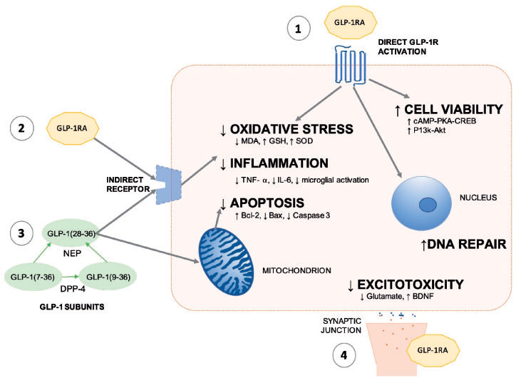

Figure 2. Proposed neuroprotective mechanism of action for GLP-1RAs in AIS.1. Direct GLP-1R activation by GLP-1RA. 2. Potential

indirect receptor activation by GLP-1RA. 3. GLP-1 sub-units are cell permeable and may affect mitochondrial function, or act on

extra-cellular receptors. 4. GLP-1RAs reduce excitotoxicity.

Maskery et al.

23

nonapeptide to have antioxidant, anti-apoptotic and

mitochondrial regulatory properties in pancreatic cells

– further research is required to establish its role in

neural tissue.<sup>59</sup>

The reduction in apoptosis, oxidative stress and

inﬂammation, alongside increased neurogenesis, angio-

genesis and cerebral blood ﬂow is likely to contribute

to the neuroprotective outcomes. Multiple signalling

cascades have been studied, with P-Akt/p-eNOS,<sup>44,50</sup>

cAMP/PKA<sup>22,45,46,49</sup>and P13k/Akt<sup>22,26,33,37,45</sup>path-

ways implicated in neuroprotection.

Clinical studies

Stroke risk in cardiovascular outcome (safety) trials.

All six licensed GLP-1RAs (Table 2) have reported

Cardiovascular Outcome Trials (CVOTs). SUSTAIN-

6 (semaglutide) and REWIND (dulaglutide) demon-

strated a signiﬁcant reduction in stroke incidence, HR

0.61 (95% CI 0.38–0.99, p ¼ 0.04) and HR 0.76 (95%

CI 0.61–0.94, p ¼ 0.017), respectively. LEADER (lira-

glutide) reported a non-statistically signiﬁcant reduc-

tion in non-fatal stroke incidence, HR 0.89 (95% CI

0.72–1.11, p ¼ 0.30). This was not reported in ELIXA

(lixisenatide),

EXSCEL

(exenatide),

HARMONY

(albiglutide) and notably not in the oral semaglutide

study, PIONEER-6.

Gerstein et al. have recently further analysed the

REWIND trial. They report that participants who

experienced stroke during follow-up were categorised

as either ischemic, hemorrhagic, or undetermined and a

modiﬁed Rankin scale (mRS) was recorded to assess

severity. Whilst dulaglutide reduced the incidence of

ischemic stroke, it did not affect stroke severity.<sup>60</sup>

Post-hoc analysis of CVOT trial data has identiﬁed

sub-groups which may potentially derive greater car-

diovascular protection. Mann et al. identiﬁed enhanced

beneﬁts in patients with chronic kidney disease,<sup>61</sup>

whilst Kang et al. reported increased beneﬁt in Asian

participants.<sup>62</sup>

Meta-analysis by Barkas et al.<sup>63</sup>demonstrated a

13% reduction in the risk of total stroke associated

with GLP-1RA treatment versus placebo (RR 0.87,

95% CI 0.78–0.98, p ¼ 0.021).

GLP-1RAs and stroke in real-world datasets. We iden-

tiﬁed eleven published retrospective studies analysing

cardiovascular outcomes of T2DM patients who had

been treated with GLP-1RAs (Table 3). These were

conducted using data extracted from insurance/nation-

al databases.

Recently, O’Brien et al. reported a retrospective

cohort study of 132 737 insured adults with T2DM

commenced on a second line diabetes medication

between 2011 and 2015.<sup>64</sup>Adjusting for confounding

variables, GLP-1RAs were associated with a reduction

in stroke risk (HR 0.65, 95% CI 0.44-0.97) when com-

pared to treatment with Dipeptidyl Peptidase-4 (DPP-

4) inhibitors. Reduction in stroke risk was reported in a

further two studies<sup>65,66</sup>; however, both Svantstrom

et al. and Anyanwagu et al. did not report this

trend.<sup>67,68</sup>

Raparelli et al. reported an increased GLP-1RA

associated reduction in cardiovascular risk in females

compared to males.<sup>69</sup>

Prospective interventional studies. Daly et al. report

the ﬁrst pilot, non-randomised interventional study

administering exenatide to eleven patients within 12 h

of stroke onset followed by twice-daily injections until

discharge.<sup>70</sup>Glucose levels were monitored, followed

by a three-month modiﬁed Rankin score. Although

mild nausea and vomiting were common, they reported

no serious adverse events nor associated hypoglycemic

episodes. They concluded that exenatide was safe and

Table 2. GLP-1RA characteristics and stroke incidence in CVOTs.

ELIXA<sup>75</sup>

LEADER<sup>76</sup>

SUSTAIN-6<sup>77</sup>

EXSCEL<sup>78</sup>

HARMONY<sup>79</sup>

REWIND<sup>80</sup>

PIONEER-6<sup>81</sup>

GLP-1RA

Lixisenatide

Liraglutide

Semaglutide

Exenatide

(extended

release)

Albiglutide

Dulaglutide

Semaglutide

Participants

6 068

9 340

3 297

14 752

9 463

9 901

3 183

Median follow-up (years)

2.1

3.8

2.1

3.2

1.6

5.4

1.3

Characteristics

Administration

Subcutaneous Subcutaneous

Subcutaneous

Subcutaneous

Subcutaneous

Subcutaneous

Oral

Dose

10–20 mg

1.8 mg

0.5–1.0mg

2 mg

30–50 mg

1.5 mg

14 mg

Frequency

once-daily

once-daily

once-weekly

once-weekly<sup>a</sup>

once-weekly

once-weekly

Once-daily

Non-fatal stroke incidence

Treatment group – no. (%) 54 (1.8)

159 (3.4)

27 (1.6)

169 (2.3)

76 (1.6)

135 (2.7)

12 (0.8)

Placebo – no. (%)

49 (1.6)

177 (3.8)

44 (2.7)

193 (2.6)

91 (1.9)

175 (3.5)

16 (1.0)

Hazard ratio (95% CI)

1.10

(0.75–1.63)

0.89 (0.72–1.11)

p ¼ 0.30

0.61 (0.38–0.99)

p ¼ 0.04

0.88 (0.72–1.08) 0.84 (0.62–1.13) 0.76 (0.61–0.94)

p ¼ 0.017

0.74 (0.35–1.57)

aExenatide standard release requires twice-daily administration.

24

Journal of Cerebral Blood Flow & Metabolism 41(1)

Table 3. Retrospective database studies.

Author

Years studied

Participants

included

Groups

Participants on

GLP-1RA

GLP-1RA CVD risk

(composite) -HR (95% CI)

unless otherwise specified

GLP-1RA Stroke

Risk -HR(95% CI)

HR Compared to

Best et al.82

2005–2009

383 525

Exenatide, non-

exenatide

21 754

0.80 (0.74–0.86)

NR

Non-exenatide

Paul et al.65

2005–2009

39 225

Exenatide, exenatide &

insulin, insulin

10 674

Exenatide 0.50 (0.32–0.79)

Exenatide and insulin

0.44 (0.34–0.57)

Exenatide

0.50(0.28–0.84)

Exenatide & insulin

0.38 (0.27–0.54)

Insulin

Gejl et al.83

1977–2011

10 073

Liraglutide, exenatide,

insulin, biguianides,

glitazones, DPP-4i,

SFU

1 749

Liraglutide OR 0.48 (0.38–0.62)

Exenatide OR 1.72 (1.20–2.48)

NR

N/A

Patorno et al.84

2005–2013

219 810

GLP-1RA, DPP-4i,

SFU, insulin

29,542

i) 1.20 (0.76–1.89)

ii) 1.05 (0.63–1.74)

iii) 1.01 (0.73–1.41)

NR

i) DPP-4i

ii) SFU

iii) insulin

Ekstr€om et al.85

2005–2012

20 422

GLP-1RA, acarbose,

insulin, DPP-4i,

meglitinide, SU,

TZD

219

0.26 (0.10–0.67)

NR

Sulphonylurea

Zimmerman et al.66

2005–2014

105 862

GLP-1RA, non-GLP-

1RA

8 362

0.82 (0.74–0.91)

0.82 (0.74–0.91)

Non-GLP-1RA

Anyanwagu et al.86

2006–2014

3 586

Insulin & GLP-1RA,

insulin

1793

0.76 (0.41–1.42)

0.93 (0.54–1.61)

Insulin

O’Brien et al.64

2011–2015

132 737

GLP-1RA, DPP-4i,

SGLT-2i, TZD, SFU,

insulin

11 351

0.78 (0.63–0.96)

0.65 (0.44–0.97)

DPP-4i

Svanstrom et al.67

2010–2016

46 804

Liraglutide, DPP-4i

23 402

0.90 (0.83–0.98)

0.88 (0.77–1.01)

DPP-4i

Raparelli et al.69

2011–2017

167 254

GLP-1RA, DPP-4i,

SGLT-2i, SFU

14 697

0.70 (0.62–0.78)

Women only:

0.57 (0.48–0.68)

NR

SFU

Note: Frison et al.87 excluded as too small to calculate HR. NR: Not recorded; DPP-4i: dipeptidyl peptidase-4 inhibitor; SFU: sulphonylurea; SGLT-2i: sodium-glucose cotransporter-2 inhibitor; TZD:

thiazolidinedione.

Maskery et al.

25

tolerable in AIS patients and did not worsen functional

or neurological outcome. This study was not sufﬁcient-

ly powered to assess for improvement in stroke

outcomes.

Larsson et al. report on PROLOGUES, a rando-

mised controlled trial comparing pre-hospital adminis-

tration

of

exenatide

with

standard

care

for

hyperglycemia in patients with suspected stroke.<sup>71</sup>

Nineteen patients were randomised, of an intended

forty two, with eight of them receiving exenatide. The

trial was stopped early due to slow inclusion—due to

baseline glucose criteria and obtaining informed con-

sent. No associated adverse events were reported.

Results are awaited for two prospective studies. The

Short-Term

EXenatide

in

Acute

ischemic

Stroke

(STEXAS) trial<sup>72</sup>is a randomised, open-label, paral-

lel-group pilot study to investigate the efﬁcacy of exe-

natide in lowering blood glucose levels in patients with

AIS and hyperglycemia. They plan to recruit 30

patients with AIS to either insulin or exenatide for up

to 72 h. They will assess feasibility of administration,

incidence of hypoglycemia and functional outcomes at

three months.

The Treatment with EXenatide in Acute Ischemic

Stroke (TEXAIS) trial<sup>73</sup>is a three-year, phase 2,

multi-centre,

prospective,

randomised,

open-label,

blinded end-point trial comparing exenatide to stan-

dard care and aims to be powered to detect a change

in neurological outcome. Primary end-point is deﬁned

as major neurological improvement at seven days (�8

point improvement in NIHSS score, or score 0–1). In

Discussion

As survival following stroke increases, so does the

impact of post-stroke disability. Alongside the ongoing

development in reperfusion therapies as part of the

gold standard of stroke care, a safe, widely applicable,

well-tolerated and cost-effective neuroprotective agent

becomes increasingly attractive.

We report a systematic review of the pre-clinical

research to support the neuroprotective properties of

GLP-1RAs targeting the ischemic-reperfusion injury in

animal models of AIS. These have been shown to be

safe and effective in normoglycemic models and dem-

onstrate neuroprotective outcomes by way of reduced

infarct volume, apoptosis, oxidative stress, inﬂamma-

tion and increased neurogenesis, angiogenesis and cere-

bral blood ﬂow. Crucially, they have demonstrated an

improvement

in

post-stroke

functional

outcomes,

including

within

both

locomotive

and

cognitive

domains.

In keeping with the real-world potential of GLP-

1RAs as a neuroprotectant in the management of

AIS, pre-clinical trials have now demonstrated repro-

ducible beneﬁts in normoglycemic models with delayed

administration up to 24 h after stroke induction.

Their neuroprotective mechanism is not fully under-

stood, with further research required. However, emerg-

ing trends towards both GLP-1R-dependent, and

independent, pathways have been reported. Following

direct comparison studies with metformin and insulin,

their effects are due to more than restoration of glucose

homeostasis. Additional research is required to fully

understand the role of cleaved GLP-1 subunits, includ-

ing GLP-1<sup>[28–36]</sup>and could go some way to explain the

difference in stroke reduction between GLP-1RAs in

CVOTs.

The economic beneﬁts of repurposing existing treat-

ments should not be overlooked, especially as the

CVOTs

have

demonstrated

their

cardiovascular

safety, alongside a reduced incidence of non-fatal

stroke. Retrospective database studies show a trend

towards a reduction in cardiovascular events, providing

an important perspective from ‘real-world’ usage.

Prospective clinical trials of GLP-1RAs in stroke are

ongoing, with initial outcomes suggestive of safety, tol-

erability and that GLP-1RAs are feasibly administered

in the AIS cohort.

The

comparative

effectiveness

of

reduction

in

overall cardiovascular risk with newer antidiabetic

treatments,

such

as

GLP-1RAs,

sodium-glucose

co-transporter-2 (SGLT-2) inhibitors and DPP-4 inhib-

itors is unclear. However, a recent network meta-

analysis has shown that only GLP-1RAs reduced

non-fatal stroke incidence (OR 0.88, 95% CI 0.77–

0.99).<sup>74</sup>

We acknowledge the limitations of this study. Pre-

clinical

studies

were

generally

conducted

on

homogenous population of young animals without rep-<sup>a</sup>

resenting the co-morbidities often afﬂicting the human

stroke population. However, one study did demon-

strate comparable neuroprotective outcomes in both

young mice and older, obese, diabetic models.<sup>25</sup>

Further research into the impact of factors such as

age, hypertension and gender is required. In addition,

studies relied on a uniform etiology of stroke onset,

vascular territory and duration of occlusion – constants

which are not representative of the diverse, heteroge-

nous clinical manifestation of AIS. However, the inter-

study differences in stroke induction protocols (e.g.

unilateral vs. bilateral, duration and vessel occlusion)

do provide some mitigation to this. Furthermore, some

studies utilized simultaneous bilateral occlusion of the

carotid arteries to cause global ischemia which would

not normally occur in human stroke; however, this

does still provide a valuable model of ischemic injury.

26

Journal of Cerebral Blood Flow & Metabolism 41(1)

We also acknowledge the effect of publication bias

favouring positive outcome and the limitations pre-

sented by the results of our STAIR and ARRIVE

assessments. The potential for under-powered research

is appreciated.

Overall,

pre-clinical

studies

are

restricted

by

small

numbers,

limited

standardisation,

disparity

between study dose and the licensed clinical dose and

having a limited ability to replicate the numerous con-

founding variables encountered in real-world stroke

practice.

Of course, CVOTs report stroke incidence rather

than stroke outcome. Other limitations include short

trial duration, complex multi-morbid patient character-

istics, and the potential for pharmacological interac-

tions

with

concomitant

medications

affecting

outcomes. GLP-1RAs are known to reduce blood pres-

sure, body weight and cholesterol, all potentially miti-

gating stroke risk. Analysis of strokes occurring within

the REWIND trial demonstrated a reduction in stroke

incidence, but no impact on stroke severity as measured

by mRS.

Retrospective studies generally included large num-

bers and are based upon real-world use and adherence.

They reported encouraging results, often demonstrat-

ing a reduction in cardiovascular risk and/or a modest

reduction in stroke risk. Eloquent attempts were

often made to adjust for confounding variables, but

these do remain a signiﬁcant limitation, as does incom-

plete extraction of events from databases.<sup>66</sup>These

studies are also limited by heterogeneity in treatment

duration, dose, and by the grouping together of

GLP-1RAs.

There remains an unfulﬁlled requirement for neuro-

protective

agents

in

the

management

of

AIS.

Ultimately, many agents have previously failed to

translate from bench to bedside.

However, we propose that further research into the

repurposing GLP-1RAs – already licensed, with estab-

lished side-effect proﬁles, cardiovascular safety record

and clear indicators from pre-clinical research of

their functional beneﬁt – is both potentially clinically

and

economically

advantageous.

Further

research

is

required

to

establish

optimal

dosing,

cost-

effectiveness, interaction with reperfusion therapies,

timing of administration, and to fully understand the

underlying mechanism of action – with consideration

of age, gender and co-morbidity – in order to guide

larger clinical trial development.

Funding

The author(s) received no ﬁnancial support for the research,

authorship, and/or publication of this article.

Declaration of conflicting interests

The author(s) declared the following potential conﬂicts of

interest with respect to the research, authorship, and/or pub-

lication of this article: CH is a named inventor on several

patent applications that cover the use of GLP-1RAs for the

treatment of neurodegenerative disorders. WDS has received

speaker honoraria, conference sponsorship by Astra-Zeneca,

Boehringer

Ingelheim,

Bristol

Myers

Squibb,

Colgate

Palmolive,

Eli

Lilly,

GlaxoSmithKline,

Lundbeck,

Menarini, Merck, Novartis, Novo Nordisk, Pﬁzer, Sanoﬁ

Aventis, Servier, and Takeda. He holds research grants

from Astra-Zeneca, Novo Nordisk and Novartis.

Authors’ contributions

All authors contributed to the study conception and design.

Material preparation, data collection and analysis were per-

formed by MM and HE. The ﬁrst draft of the manuscript was

written by MM and all authors commented on previous ver-

sions of the manuscript. All authors read and approved the

ﬁnal manuscript.

Ethical approval

This systematic review does not contain any new studies with

human participants or animal performed by any of the

authors.

ORCID iDs

Mark P Maskery

https://orcid.org/0000-0001-5661-6267

Christian Holscher

https://orcid.org/0000-0002-8159-3260

References

1. Feigin VL, Norrving B and Mensah GA. Global burden

of stroke. Circ Res 2017; 120: 439–448.

2. Feigin VL, Forouzanfar MH, Krishnamurthi R, et al.

Global and regional burden of stroke during 1990–

2010: ﬁndings from the Global Burden of Disease

Study 2010. Lancet 2014; 383: 245–255.

3. McMeekin P, White P, James MA, et al. Estimating the

number of UK stroke patients eligible for endovascular

thrombectomy. Eur Stroke J 2017; 2: 319–326.

4. Goyal

M,

Menon

BK,

van

Zwam

WH,

et

al.

Endovascular thrombectomy after large-vessel ischaemic

stroke: a meta-analysis of individual patient data from

ﬁve randomised trials. Lancet 2016; 387: 1723–1731.

5. Wardlaw JM, Murray V, Berge E, et al. Thrombolysis for

acute ischaemic stroke. Cochrane Database Syst Rev

2014; 7: 18.

6. Neuhaus

AA,

Couch

Y,

Hadley

G,

et

al.

Neuroprotection in stroke: the importance of collabora-

tion and reproducibility. Brain 2017; 140: 2079–2092.

7. Fisher M, Feuerstein G, Howells DW, et al. Update of

the stroke therapy academic industry roundtable preclin-

ical recommendations. Stroke 2009; 40: 2244–2250.

8. Shi S, M€orike K and Klotz U. The clinical implications

of ageing for rational drug therapy. Eur J Clin Pharmacol

2008; 64: 183–199.

Maskery et al.

27

9. Hurn PD, Vannucci SJ and Hagberg H. Adult or perina-

tal brain injury: does sex matter? Stroke 2005; 36:

193–195.

10. O’Collins VE, Macleod MR, Donnan GA, et al. 1,026

Experimental treatments in acute stroke. Ann Neurol

2006; 59: 467–477.

11. Sutherland

BA,

Minnerup

J,

Balami

JS,

et

al.

Neuroprotection for ischaemic stroke: translation from

the bench to the bedside. Int J Stroke 2012; 7: 407–418.

12. H€olscher C. Potential role of glucagon-like peptide-1

(GLP-1) in neuroprotection. CNS Drugs 2012; 26:

871–882.

13. Gallwitz B. Extra-pancreatic effects of incretin-based

therapies. Endocrine 2014; 47: 360–371.

14. H€olscher C. Central effects of GLP-1: new opportunities

for

treatments

of

neurodegenerative

diseases.

J

Endocrinol 2014; 221: T31–T41.

15. Boland A, Cherry G and Dickson R. Doing a systematic

review:

a

student’s

guide.

1st

ed.

London:

Sage

Publications, 2013.

16. Kilkenny C, Browne WJ, Cuthill IC, et al. Improving

bioscience research reporting: the ARRIVE Guidelines

for Reporting Animal Research. PLoS Biol 2010; 8:

e1000412.

17. Hyun Lee C, Yan B, Yoo K-Y, et al. Ischemia-induced

changes in glucagon-like peptide-1 receptor and neuro-

protective effect of its agonist, exendin-4, in experimental

transient cerebral ischemia. J Neurosci Res 2011; 89:

1103–1113.

18. Li Y, Perry T, Kindy MS, et al. GLP-1 receptor stimu-

lation preserves primary cortical and dopaminergic neu-

rons in cellular and rodent models of stroke and

Parkinsonism. Proc Natl Acad Sci 2009; 106: 1285–1290.

19. Briyal S, Gulati K and Gulati A. Repeated administra-

tion of exendin-4 reduces focal cerebral ischemia-induced

infarction in rats. Brain Res 2012; 1427: 23–34.

20. Darsalia V, Mansouri S, Orts€ater H, et al. Glucagon-like

peptide-1 receptor activation reduces ischaemic brain

damage following stroke in Type 2 diabetic rats. Clin

Sci 2012; 122: 473–483.

21. Jia Y, Gong N, Li T-F, et al. Peptidic exenatide and

herbal catalpol mediate neuroprotection via the hippo-

campal

GLP-1

receptor/b-endorphin

pathway.

Pharmacol Res 2015; 102: 276–285.

22. Zhang H, Meng J, Zhou S, et al. Intranasal delivery of

exendin-4 confers neuroprotective effect against cerebral

ischemia in mice. AAPS J 2016; 18: 385–394.

23. Kim S, Jeong J, Jung H-S, et al. Anti-inﬂammatory effect

of glucagon like peptide-1 receptor agonist, exendin-4,

through modulation of IB1/JIP1 expression and JNK sig-

naling in stroke. Exp Neurobiol 2017; 26: 227.

24. Teramoto S, Miyamoto N, Yatomi K, et al. Exendin-4, a

glucagon-like peptide-1 receptor agonist, provides neuro-

protection in mice transient focal cerebral ischemia. J

Cereb Blood Flow Metab 2011; 31: 1696–1705.

25. Darsalia V, Hua S, Larsson M, et al. Exendin-4 reduces

ischemic brain injury in normal and aged type 2 diabetic

mice and promotes microglial M2 polarization. PLoS

ONE 2014; 9: e103114.

26. Chen F, Wang W, Ding H, et al. The glucagon-like pep-

tide-1 receptor agonist exendin-4 ameliorates warfarin-

associated hemorrhagic transformation after cerebral

ischemia.

J

Neuroinﬂammation

2016;

13:

204.

DOI:10.1186/s12974-016-0661-0.

27. Kuroki T, Tanaka R, Shimada Y, et al. Exendin-4 inhib-

its matrix metalloproteinase-9 activation and reduces

infarct growth after focal cerebral ischemia in hypergly-

cemic mice. Stroke 2016; 47: 1328–1335.

28. Yang J-L, Chen W-Y, Chen Y-P, et al. Activation of

GLP-1 receptor enhances neuronal base excision repair

via PI3K-AKT-induced expression of apurinic/apyrimi-

dinic endonuclease 1. Theranostics 2016; 6: 2015–2027.

29. Briyal S, Shah S and Gulati A. Neuroprotective and anti-

apoptotic effects of liraglutide in the rat brain following

focal cerebral ischemia. Neuroscience 2014; 281: 269–281.

30. Deng C, Cao J, Han J, et al. Liraglutide activates the

Nrf2/HO-1 antioxidant pathway and protects brain

nerve cells against cerebral ischemia in diabetic rats.

Comput Intell Neurosci 2018; 2018: 1–7.

31. Filchenko

I,

Simanenkova

A,

Chefu

S,

et

al.

Neuroprotective effect of glucagon-like peptide-1 receptor

agonist is independent of glycaemia normalization in type

two diabetic rats. Diab Vasc Dis Res 2018; 15: 567–570.

32. Sato K, Kameda M, Yasuhara T, et al. Neuroprotective

effects of liraglutide for stroke model of rats. Int J Mol

Sci 2013; 14: 21513–21524.

33. Zhu H, Zhang Y, Shi Z, et al. The neuroprotection of

liraglutide against ischaemia-induced apoptosis through

the activation of the PI3K/AKT and MAPK pathways.

Sci Rep 2016; 6: 26859. DOI:10.1038/srep26859.

34. Dong W, Miao Y, Chen A, et al. Delayed administration

of the GLP-1 receptor agonist liraglutide improves met-

abolic and functional recovery after cerebral ischemia in

rats. Neurosci Lett 2017; 641: 1–7.

35. Chen Y, Zhang X, He J, et al. Delayed administration of

the glucagon-like peptide 1 analog liraglutide promoting

angiogenesis after focal cerebral ischemia in mice. J

Stroke Cerebrovasc Dis 2018; 27: 1318–1325.

36. He W, Wang H, Zhao C, et al. Role of liraglutide in brain

repair promotion through Sirt1-mediated mitochondrial

improvement

in

stroke.

J

Cell

Physiol

2020;

235:

2986–3001.

37. Zeng S, Bai J, Jiang H, et al. Treatment with liraglutide

exerts

neuroprotection

after

hypoxic–ischemic

brain

injury in neonatal rats via the PI3K/AKT/GSK3b path-

way. Front Cell Neurosci 2020; 13: 585. DOI:10.3389/

fncel.2019.00585.

38. Jiang D, Wang Y, Zang Y, et al. Neuroprotective Effects

of rhGLP-1 in diabetic rats with cerebral ischemia/reper-

fusion injury: rhGLP-1 neuroprotective beneﬁts. Drug

Dev Res 2016; 77: 124–133.

39. Fang Y, Jiang D, Wang Y, et al. Neuroprotection of

rhGLP-1 in diabetic rats with cerebral ischemia/reperfu-

sion injury via regulation of oxidative stress, EAAT2,

and apoptosis. Drug Dev Res 2018; 79: 249–259.

40. Zhao L, Xu J, Wang Q, et al. Protective effect of rhGLP-

1 (7–36) on brain ischemia/reperfusion damage in diabet-

ic rats. Brain Res 2015; 1602: 153–159.

28

Journal of Cerebral Blood Flow & Metabolism 41(1)

41. Abdel-latif RG, Heeba GH, Taye A, et al. Lixisenatide

ameliorates

cerebral

ischemia-reperfusion

injury

via

GLP-1 receptor dependent/independent pathways. Eur

J Pharmacol 2018; 833: 145–154.

42. Abdel-latif RG, Heeba GH, Taye A, et al. Lixisenatide, a

novel GLP-1 analog, protects against cerebral ischemia/

reperfusion injury in diabetic rats. Naunyn Schmiedebergs

Arch Pharmacol 2018; 391: 705–717.

43. Yang X, Feng P, Zhang X, et al. The diabetes drug sem-

aglutide reduces infarct size, inﬂammation, and apopto-

sis, and normalizes neurogenesis in a rat model of stroke.

Neuropharmacology 2019; 158: 107748.

44. Chien C-T, Jou M-J, Cheng T-Y, et al. Exendin-4-loaded

PLGA microspheres relieve cerebral ischemia/reperfusion

injury and neurologic deﬁcits through long-lasting bioac-

tivity-mediated phosphorylated Akt/eNOS signaling in

rats. J Cereb Blood Flow Metab 2015; 35: 1790–1803.

45. Zhang H, Meng J, Li X, et al. Pro-GLP-1, a Pro-drug of

GLP-1, is neuroprotective in cerebral ischemia. Eur J

Pharm Sci 2015; 70: 82–91.

46. Zhang H, Liu Y, Guan S, et al. An orally active allosteric

GLP-1 receptor agonist is neuroprotective in cellular and

rodent models of stroke. PLoS ONE 2016; 11: e0148827.

47. Han L, Holscher C, Xue G, et al. A novel dual-glucagon-

like peptide 1 and glucose-dependent insulinotrophic

polypeptide receptor agonist is neuroprotective in tran-

sient focal cerebral ischaemia in the rat. Neuroreport

2016; 6: 23–32.

48. Li Y, Wu K-J, Yu S-J, et al. Neurotrophic and neuro-

protective effects of oxyntomodulin in neuronal cells and

a rat model of stroke. Exp Neurol 2017; 288: 104–113.

49. Wang Y-H, Liou K-T, Tsai K-C, et al. GSK-3 inhibition

through GLP-1R allosteric activation mediates the neu-

rogenesis promoting effect of P7C3 after cerebral ische-

mic/reperfusional injury in mice. Toxicol Appl Pharmacol

2018; 357: 88–105.

50. Li P-C, Liu L-F, Jou M-J, et al. The GLP-1 receptor ago-

nists exendin-4 and liraglutide alleviate oxidative stress and

cognitive and micturition deﬁcits induced by middle cere-

bral artery occlusion in diabetic mice. BMC Neurosci 2016;

17: 50. DOI: 10.1186/s12868-016-0272-9.

51. Gad SN, Nofal S, Raafat EM, et al. Lixisenatide reduced

damage in hippocampus CA1 neurons in a rat model of

cerebral ischemia-reperfusion possibly via the ERK/P38

signaling pathway. J Mol Neurosci 2020; 70: 1026–1037.

DOI: 10.1007/s12031-020-01497-9.

52. Pawlowski J and Kraft AS. Bax-induced apoptotic cell

death. Proc Natl Acad Sci 2000; 97: 529–531.

53. Chaitanya G, Alexander JS and Babu P. PARP-1 cleav-

age fragments: signatures of cell-death proteases in neu-

rodegeneration. Cell Commun Signal 2010; 8: 31.

54. Porter AG and J€anicke RU. Emerging roles of caspase-3

in apoptosis. Cell Death Differ 1999; 6: 99–104.

55. Darzynkiewicz Z, Galkowski D and Zhao H. Analysis of

apoptosis by cytometry using TUNEL assay. Methods

2008; 44: 250–254.

56. Wilkins HM and Swerdlow RH. TNFa in cerebral ische-

mia: another stroke against you? J Neurochem 2015; 132:

369–372.

57. Bell AH, Miller SL, Castillo-Melendez M, et al. The neu-

rovascular unit: effects of brain insults during the perina-

tal period. Front Neurosci 2020; 13: 1452. DOI: 10.3389/

fnins.2019.01452.

58. Ma Y, Zechariah A, Qu Y, et al. Effects of vascular

endothelial growth factor in ischemic stroke. J Neurosci

Res 2012; 90: 1873–1882.

59. Zhou B, Ji K, Peng A, et al. GLP-1(28-36)amide, a long

ignored peptide revisited. Open Biochem J 2014; 8:

107–111.

60. Gerstein HC, Hart R, Colhoun HM, et al. The effect of

dulaglutide on stroke: an exploratory analysis of the

REWIND trial. Lancet Diab Endocrinol 2020; 8: 106–114.

61. Mann JFE, Fonseca V, Mosenzon O, et al. Effects of

liraglutide versus placebo on cardiovascular events in

patients with type 2 diabetes mellitus and chronic

kidney

disease:

results

from

the

LEADER

Trial.

Circulation 2018; 138: 2908–2918.

62. Kang YM, Cho YK, Lee J, et al. Asian subpopulations

may exhibit greater cardiovascular beneﬁt from long-

acting glucagon-like peptide 1 receptor agonists: a

meta-analysis of cardiovascular outcome trials. Diabetes

Metab J 2018; 42.

63. Barkas F, Elisaf M and Milionis H. Protection against

stroke with glucagon-like peptide 1 receptor agonists: a

systematic review and meta-analysis. Eur J Neurol 2019;

26: 559–565. DOI: 10.1111/ene.13905.

64. O’Brien MJ, Karam SL, Wallia A, et al. Association of

second-line antidiabetic medications with cardiovascular

events among insured adults with type 2 diabetes. JAMA

Netw Open 2018; 1: e186125.

65. Paul SK, Klein K, Maggs D, et al. The association of the

treatment with glucagon-like peptide-1 receptor agonist

exenatide or insulin with cardiovascular outcomes in

patients with type 2 diabetes: a retrospective observation-

al study. Cardiovasc Diabetol 2015; 14: 10.

66. Zimmerman RS, Hobbs TM, Wells BJ, et al. Association

of glucagon-like peptide-1 receptor agonist use and rates

of acute myocardial infarction, stroke and overall mor-

tality in patients with type 2 diabetes mellitus in a large

integrated health system. Diabetes Obes Metab 2017; 19:

1555–1561.

67. Svanstr€om H, Ueda P, Melbye M, et al. Use of liraglutide

and risk of major cardiovascular events: a register based

cohort study in Denmark and Sweden. Lancet Diab

Endocrinol 2019; 7: 106–114.

68. Anyanwagu U, Mamza J, Mehta R, et al. Cardiovascular

events

and

all-cause

mortality

with

insulin

versus

glucagon-like peptide-1 analogue in type 2 diabetes.

Heart 2016; 102: 1581–1587.

69. Raparelli V, Elharram M, Moura CS, et al. Sex differ-

ences in cardiovascular effectiveness of newer glucose-

lowering drugs added to metformin in type 2 diabetes

mellitus.

J

Am

Heart

Assoc

2020;

9:

e012940.

doi:10.1161/JAHA.119.012940.

70. Daly SC, Chemmanam T, Loh P-S, et al. Exenatide in

acute ischemic stroke. Int J Stroke 2013; 8: E44–E44.

71. Larsson M, Castren M, Lindstr€om V, et al. Prehospital

exenatide in hyperglycemic stroke – a randomized trial.

Maskery et al.

29

Acta Neurol Scand 2019; 140: 443–448. DOI: 10.1111/

ane.13166.

72. McGrath RT, Hocking SL, Priglinger M, et al. Rationale

and design of Short-Term EXenatide therapy in Acute

ischaemic Stroke (STEXAS): a randomised, open-label,

parallel-group study. BMJ Open 2016; 6: e008203.

73. Muller C, Cheung NW, Dewey H, et al. Treatment with

exenatide in acute ischemic stroke trial protocol: a pro-

spective, randomized, open label, blinded end-point study

of exenatide vs. standard care in post stroke hyperglyce-

mia. Int J Stroke 2018; 13: 857–862.

74. Fei Y, Tsoi M-F and Cheung BMY. Cardiovascular out-

comes in trials of new antidiabetic drug classes: a network

meta-analysis. Cardiovasc Diabetol 2019; 18: 112. DOI:

10.1186/s12933-019-0916-z.

75. Pfeffer MA, Claggett B, Diaz R, et al. Lixisenatide in

patients with type 2 diabetes and acute coronary syn-

drome. N Engl J Med 2015; 373: 2247–2257.

76. Marso SP, Daniels GH, Brown-Frandsen K, et al.

Liraglutide and cardiovascular outcomes in type 2 diabe-

tes. N Engl J Med 2016; 375: 311–322.

77. Marso SP, Bain SC, Consoli A, et al. Semaglutide and

cardiovascular outcomes in patients with type 2 diabetes.

N Engl J Med 2016; 375: 1834–1844.

78. Holman RR, Bethel MA, Mentz RJ, et al. Effects of

once-weekly exenatide on cardiovascular outcomes in

type 2 diabetes. N Engl J Med 2017; 377: 1228–1239.

79. Hernandez

AF,

Green

JB,

Janmohamed

S,

et

al.

Albiglutide and cardiovascular outcomes in patients

with

type

2

diabetes

and

cardiovascular

disease

(Harmony

Outcomes):

a

double-blind,

randomised

placebo-controlled trial. Lancet 2018; 392: 1519–1529.

80. Gerstein HC, Colhoun HM, Dagenais GR, et al.

Dulaglutide and cardiovascular outcomes in type 2

diabetes

(REWIND):

a

double-blind,

randomised

placebo-controlled trial. Lancet 2019; 394: 121–130.

81. Husain M, Birkenfeld AL, Donsmark M, et al. Oral sem-

aglutide and cardiovascular outcomes in patients with

type 2 diabetes. N Engl J Med 2019; 381: 841–851.

82. Best JH, Hoogwerf BJ, Herman WH, et al. Risk of car-

diovascular disease events in patients with type 2 diabetes

prescribed the glucagon-like peptide 1 (GLP-1) receptor

agonist exenatide twice daily or other glucose-lowering

therapies: a retrospective analysis of the LifeLink data-

base. Diab Care 2011; 34: 90–95.

83. Gejl M, Starup-Linde J, Scheel-Thomsen J, et al. Risk of

cardiovascular disease: the effects of diabetes and anti-

diabetic drugs – a nested case–control study. Int J Cardiol

2015; 178: 292–296.

84. Patorno E, Everett BM, Goldﬁne AB, et al. Comparative

cardiovascular safety of glucagon-like peptide-1 receptor

agonists versus other antidiabetic drugs in routine care: a

cohort study. Diab Obes Metab 2016; 18: 755–765.

85. Ekstr€om

N,

Svensson

A-M,

Miftaraj

M,

et

al.

Cardiovascular safety of glucose-lowering agents as

add-on medication to metformin treatment in type 2 dia-

betes:

report

from

the

Swedish

National

Diabetes

Register. Diabetes Obes Metab 2016; 18: 990–998.

86. Anyanwagu U, Mamza J, Donnelly R, et al. Effect of

adding GLP-1RA on mortality, cardiovascular events,

and metabolic outcomes among insulin-treated patients

with type 2 diabetes: a large retrospective UK cohort

study. Am Heart J 2018; 196: 18–27.

87. Frison V, Simioni N, Marangoni A, et al. Clinical impact

of 5 years of liraglutide treatment on cardiovascular risk

factors in patients with type 2 diabetes mellitus in a real-

life setting in Italy: an observational study. Diabetes Ther

2018; 9: 2201–2208.

30

Journal of Cerebral Blood Flow & Metabolism 41(1)